# Run pSBVB addtional functions

14 de septiembre de 2018

## Purpose

Polyploidy is a very common event in plants and in some fish species, too. However, the application of Genomic Selection (GS) in polyploids organism is still scarse and to the date, a few number of studies has been published.

Computer simulation allows the exploration of a wide range of hypothesis at low cost and they can help to interpret the outcome of selection in complex situations. The purpose of this study is to develop a flexible simulation tool and to propose several approaches to compute the molecular relationship matrix adapted to polyploids, as well as the implementation of phenotypes simulations.

The current framework shows how the program works using a toy example of octoploid strawberry (F. $\times$ ananassa) SNPs and a toy dataset from autotetraploid potato.

As input, the software requiered a chipset (list of markers through the genome), a vcf file (lists with genotypes in vcf format), a pedigree file (file with crosses to perform simulations using gene dropping) and a parameter file. In order to facilitate the software usage, we recommend that you have all these files in a same folder. The software outputs are phenotypes and genotypes matrices able to perform GS models. The next figure shows the general Software’ view.

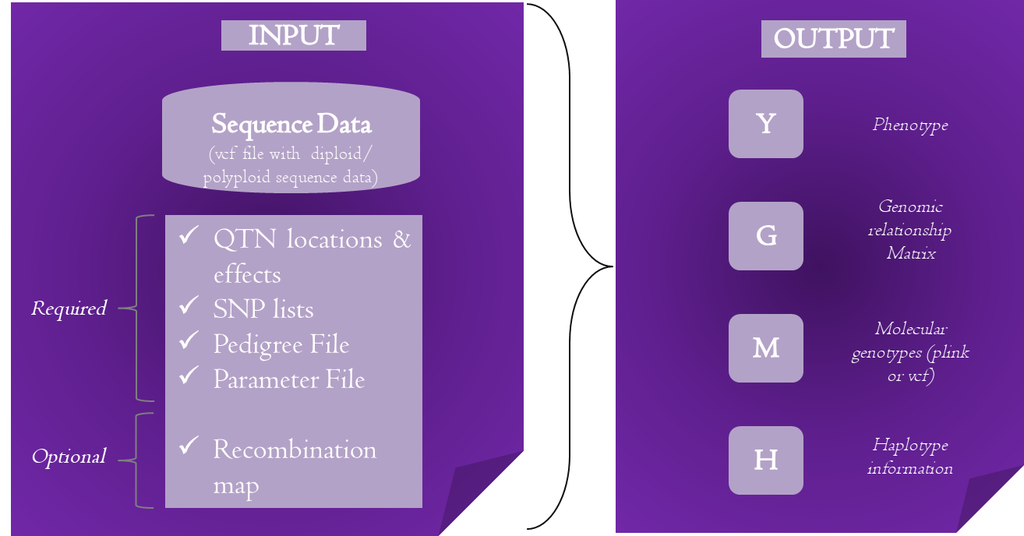

General Software’ View

## Main features

- Any number of traits.
- Tool adapted to work with both, auto and allo-polyploid organisms.
- Any number of QTNs, trait specific.
- Any number of additive and dominant effects.
- Can generate a correlation matrix to modelate meiosis in polyploid especies.
- Can generate correlated allelic effects and frequencies.
- Efficient algorithms to generate haplotypes and sample SNP genotypes.
- Computes genomic relationship matrices for any number of SNP arrays simultaneously.
- It allow to compute Genomic relationship matrix in several ways.
- Any number of chromosomes, allows for sex chromosomes and varying local recombination rates, that can be sex specific.

# Installation

The source code, manual and examples can be obtained from https://github.com/lzingaretti/pSBVB

To compile:

```
gfortran -O3 kind.f90 ALliball.f90 aux_sub11.f90 psbvb.f90 -o sbvb -lblas
```

or

```
make
```

To install in /usr/local/bin

```
sudo make install
```

The program requires blas libraries but these are standard in any unix or OS mac system. We have tested pSBVB only in linux with gfortran compiler; intel ifort seems not working, but gfortran in mac OS looks ok. Usage

To run:

```
 file.vcf psbvb -isbvb.par
```

To run the program with the same random seed:

```
… | psbvb –isbvb.par –seed iseed
```

where iseed is an integer number

# Prepare your files

## Function to create a pedigree to use as .ped file

Pedigree file is required to simulations. The number of founder individuals have to be equal or higher than the number of inviduals in .gen (or .vcf) file. The founders are those individuals whith genomic information.

We provide a R function to generate pedigree file. You can choose any number of founder, generation, individuals by generation and sex specification is optional as well.

### Example 1: Generate a pedigree file

```
source("pedigree.R")
M<-pedgenerator(100,4,c(rep(100,3),150),
   sex=FALSE,
   path="~/Dropbox/DoctoradoCRAG/paper-1/article/software-help/reversinn1/pSBVB/
   toy_strawberry/Additional_functions",exclude=47)
tail(M$pedigree)
```

```
source("pedigree.R")
M<-pedgenerator(100,4,c(rep(100,3),150),sex=FALSE,
   path="~/Dropbox/DoctoradoCRAG/paper-1/article/software-help/reversinn1/pSBVB/toy_strawberry/
   Additional_functions",exclude=47)

tail(M$pedigree)
```

## Generate a pedigree based relationship matrix

We had implemented a R function to generate a Relationship matrix to compare with genomic relationship matrix. Our function could be used to compute both, additive and dominant relationship matrices. To do the calculation, a pedigree file is needed as input. You can to use the pedigree matrix generated with pedigree.R as input.

```
source("RelationshipMatrix.R")
data<-read.table("~/Dropbox/DoctoradoCRAG/paper-1/article/software-help/reversinn1/pSBVB
                 /toy_strawberry/Additional_functions/File_st.ped",header=FALSE)
#check the dimensions of dataset
dim(data)
A<-RelMatrix(data,dominance=FALSE,path= "~/Dropbox/DoctoradoCRAG/paper-1/article/software-help/reversinn1/pSBVB/toy_strawberry/Additional_functions/")
tail(A)
```

# Application examples

## Example: Generate strawberry simulated genotype + phenotype dataset using the previous pedigree file and several options.

The parameter file (see file_1.par) incorporate three “H2” parameter of 0.3, 0.4 and 0.5. 150 causals SNP’s to simulate the phenotype. This file simulated simultaneosly three pheno types with three additive effects. The Genomic Relationship matrix is generated using Gtota, then the M values varying between 0 and 8. The others files have the next options:

- file_4.par –> heredability of 0.5, generate 1 trait. Use GT as genomic relationship matrix. Additive and dominat effects are simulated from a gamma distribution with mean=0.2, shape= 0.2 and mean= 0.2, shape= 0.5 parameters respectively.
- file_5.par –> heredability of 0.3, generate 1 trait. Use GT as genomic relationship matrix, 80 QTNS

You can run all files simultaneosly using run_toy_st.sh file. You could run the program once:

```bash
cat toy_st.gen | sbvb -i file_1.par
```

or using a .sh file:

```
./run_toy_st.sh
```

The next images show how it works:

[figure not shown]

[figure not shown]

Run the program several times simultaneosly using a bash script

# Statistical Models:

There are numerous GS methods that use genome-wide markers to predict breeding values and address the large $p$ small $n$ problem. Here, breeding values were predicted using GBLUP, which is a genomic-based extension of traditional BLUP (Henderson, 1984) and equivalent to Ridge Regression Model (RR-BLUP). The model is:

$$\begin{equation}
\mathbf{y}=\mathbf{1^T}\mu+\mathbf{Z}u+\epsilon_i
\label{eq:equation5}
\end{equation}$$

The R script to perform Predictive abilities is GBlupFunction.R

## Running Model 1

```r
library(ggplot2)
source("GBlupFunction.R")
setwd("/home/laura/Dropbox/DoctoradoCRAG/paper-1/article/software-help/reversinn1/pSBVB/toy_strawberry/results_example1/")

G<- read.table("Y.grm.1")
y<- read.table("Y.outy")
#check matrix dimention
dim(y)
```

```
## [1] 503  13
```

```r
dim(G)
```

```
## [1] 503 503
```

```r
#In the example one, we had been simulated three phenotypes simultaneosly. The GBlup Prediction, could be used to evaluated predictive of those traits ability simultaneosly.
h2=c(0.3,0.4,0.5)
ntraits=3
make_predictions=c(353:503)
library(ggplot2)
S<-GBlup_predict(G=G,y=y,h2=h2,make_predictions=make_predictions,ntraits=ntraits)
S[[3]]$rho
```

```
## [1] 0.6608666
```

```r
Phenohat<-S[[3]]$uhat[make_predictions] + S[[3]]$mean
Pheno<-S[[3]]$yout_corr[make_predictions]
cor(Pheno,Phenohat)
```

```
## [1] 0.6608666
```

```r
datos<-data.frame(Phenohat,Pheno)
colnames(datos)<-c("Yhat","Y")
apply(datos,2,class)
```

```
##      Yhat         Y
## "numeric" "numeric"
```

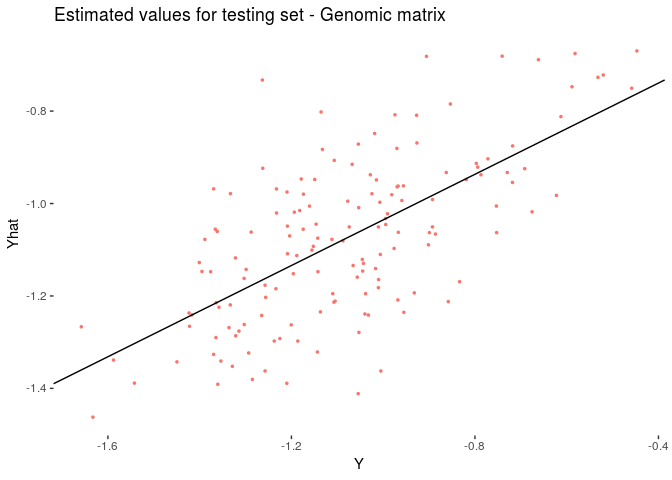

```r
ggplot(datos, aes(y=Yhat, x=Y,colour="red")) +
geom_point(size=0.6) + scale_shape_manual(values=c(2,4)) +
ggtitle("Estimated values for testing set - Genomic matrix") +
geom_abline(intercept=lm(Yhat ~ Y,data=datos)$coefficients[1], slope=lm(Yhat ~ Y,data=datos)$coefficients[2])+
#scale_x_continuous(limits = c(min(datos[,1]), max(datos[,1])))+
#scale_y_continuous(limits = c(min(datos[,2]), max(datos[,2])))+

theme(panel.background = element_blank(),
    panel.grid.major = element_blank(),
    panel.grid.minor = element_blank(), legend.position ="none")
```

# Running Model 2

Model 4 incorporates dominant effects

```r
source("GBlupFunction.R")
setwd("/home/laura/Dropbox/DoctoradoCRAG/paper-1/article/software-help/reversinn1/pSBVB/toy_strawberry/results_example4/")

G<- read.table("Y.grm.1")
y<- read.table("Y.outy")
#check matrix dimention
dim(y)
```

```
## [1] 503   5
```

```r
dim(G)
```

```
## [1] 503 503
```

```r
setwd("/home/laura/Dropbox/DoctoradoCRAG/paper-1/article/software-help/reversinn1/pSBVB/toy_strawberry/")

R<-read.table("Relationship.mat")
#check matrix dimention
dim(R)
```

```
## [1] 550 550
```

```r
R<-R[c(48:550),c(48:550)]
#In the example one, we had been simulated three phenotypes simultaneosly. The GBlup Prediction, could be used to evaluated predictive of those traits ability simultaneosly.
h2=0.5
ntraits=1
make_predictions=c(354:503)

S<-GBlup_predict(G=G,y=y,h2=h2,make_predictions=c(354:503),ntraits=ntraits)
SR<-GBlup_predict(G=R,y=y,h2=h2,make_predictions=c(354:503),ntraits=ntraits)
S$rhoM
```

```
## [1] 0.6859251
```

```r
SR$rhoM
```

```
## [1] 0.416766
```

# Running Model 3

```r
source("GBlupFunction.R")
setwd("/home/laura/Dropbox/DoctoradoCRAG/paper-1/article/software-help/reversinn1/pSBVB/toy_strawberry/results_example5/")

G<- read.table("Y.grm.1")
y<- read.table("Y.outy")
#check matrix dimention
dim(y)
```

```
## [1] 503   5
```

```r
dim(G)
```

```
## [1] 503 503
```

```r
setwd("/home/laura/Dropbox/DoctoradoCRAG/paper-1/article/software-help/reversinn1/pSBVB/toy_strawberry/")

R<-read.table("Relationship.mat")
#check matrix dimention
dim(R)
```

```
## [1] 550 550
```

```r
R<-R[c(48:550),c(48:550)]
#In the example one, we had been simulated three phenotypes simultaneosly. The GBlup Prediction, could be used to evaluated predictive of those traits ability simultaneosly.
h2=0.3
ntraits=1
make_predictions=c(354:503)

S<-GBlup_predict(G=G,y=y,h2=h2,make_predictions=c(354:503),ntraits=ntraits)
SR<-GBlup_predict(G=R,y=y,h2=h2,make_predictions=c(354:503),ntraits=ntraits)
S$rhoM
```

```
## [1] 0.5327408
```

```r
SR$rhoM
```

```
## [1] 0.2355178
```

# Examples with potato dataset:

```r
setwd("/home/laura/Dropbox/DoctoradoCRAG/paper-1/article/software-help/reversinn1/pSBVB/toy_strawberry/Additional_functions/")
source("pedigree.R")
source("RelationshipMatrix.R")
```

```
## Completed! Time = 0.0013  minutes
```

```r
source("GBlupFunction.R")
source("generate_vcf_from_gen.R")
```

We also created a function to transformate genotypes into ‘vcf’ format. To do that, you need a dataset with genotypes (data varying between 0 and ploidy level) and a map file, containing the SNP’s physical coordinates. We used genotypes from potato database (https://figshare.com/articles/Supplemental_Material_for_Enciso-Rodriguez_et_al_2018/6262214). Note that, our function generate the vcf file randomly from genotype (unphased data). In order to generate Linkage Disequilibrium, we could combine two pSBVB parameters: EXPAND_BASEPOP and INDFIRST, which simultaneosly exclude the initial individuals and generate a new set of founder.

Furthermore, the FilesGenerator.R file have all the functions needed to create a Chip, pedigree, QTNs location files and run potato example.

```r
setwd("/home/laura/Dropbox/DoctoradoCRAG/paper-1/article/software-help/reversinn1/pSBVB/toy_potato/")
#read map file
map<-read.table("Sol_tet_mapa.map",sep="\t")
#read genotype
G<-read.delim("Pot_gen.gen",sep="\t")
#select a sub-sample from whole dataset
G=G[sample(c(1:nrow(G)),150),]
G=G[,sample(c(1:ncol(G)),500)]
G<-G[,colnames(G)%in%map[,1]]
dim(G)
```

```
## [1] 150 410
```

```r
#generate genotypes vcf format
A=GenotoVcf(G,p=4,map,path="NULL")
library(ggplot2)
setwd("/home/laura/Dropbox/DoctoradoCRAG/paper-1/article/software-help/reversinn1/pSBVB/toy_strawberry/Additional_functions/")
source("GBlupFunction.R")

data<-read.table("/home/laura/Dropbox/DoctoradoCRAG/paper-1/article/software-help/reversinn1/pSBVB/toy_potato/File_st.ped",header=FALSE)
#check the dimensions of dataset
#generate relationship matrix
dim(data)
```

```
## [1] 700   3
```

```r
A<-RelMatrix(data,dominance=FALSE,path="/home/laura/Dropbox/DoctoradoCRAG/paper-1/article/software-help/reversinn1/pSBVB/toy_potato/")
```

```
## Completed! Time = 0.001983333  minutes
```

```r
setwd("/home/laura/Dropbox/DoctoradoCRAG/paper-1/article/software-help/reversinn1/pSBVB/toy_potato/results_potato/")

G<- read.table("Y.grm.1")
y<- read.table("Y.outy")
RelMatrix<-A[-c(1:150),-c(1:150)]


h2=0.5
ntraits=1

make_predictions=c(401:550)
library(ggplot2)
S<-GBlup_predict(G=G,y=y,h2=h2,make_predictions=make_predictions,ntraits=ntraits)
S$rho
```

```
## [1] 0.5222637
```

```r
Phenohat<-S$uhat[make_predictions] + S$mean
Pheno<-S$yout_corr[make_predictions]
cor(Pheno,Phenohat)
```

```
## [1] 0.5222637
```

```r
datos<-data.frame(Phenohat,Pheno)
colnames(datos)<-c("Yhat","Y")
apply(datos,2,class)
```

```
##      Yhat         Y
## "numeric" "numeric"
```

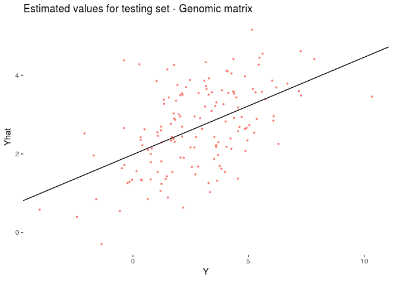

```r
ggplot(datos, aes(y=Yhat, x=Y,colour="red")) +
  ggtitle("Estimated values for testing set - Genomic matrix")+
  geom_point(size=0.6) + scale_shape_manual(values=c(2,4)) +
  geom_abline(intercept=lm(Yhat ~ Y,data=datos)$coefficients[1], slope=lm(Yhat ~ Y,data=datos)$coefficients[2])+
  #scale_x_continuous(limits = c(min(datos[,1]), max(datos[,1])))+
  #scale_y_continuous(limits = c(min(datos[,2]), max(datos[,2])))+

  theme(panel.background = element_blank(),
        panel.grid.major = element_blank(),
        panel.grid.minor = element_blank(), legend.position ="none")
```

```r
make_predictions=c(401:550)


SR<-GBlup_predict(G=RelMatrix,y=y,h2=h2,make_predictions=c(401:550),ntraits=ntraits)
SR$rhoM
```

```
## [1] 0.3024539
```

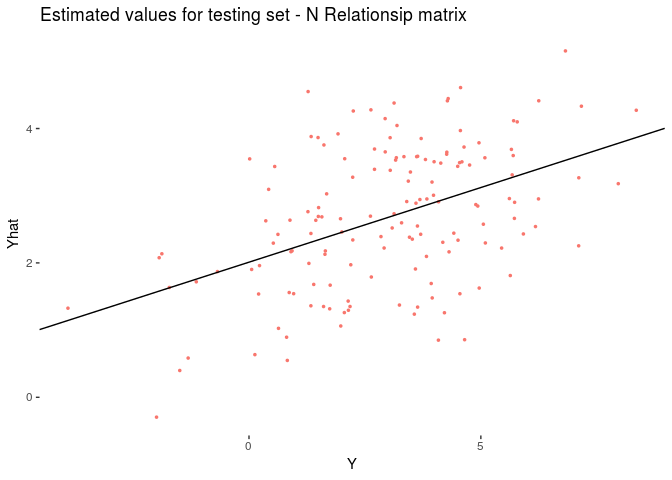

```r
Pheno<-SR$yout_corr[make_predictions]
datos_r<-data.frame(Phenohat,Pheno)
colnames(datos_r)<-c("Yhat","Y")

#Pedigree Prediction
ggplot(datos_r, aes(y=Yhat, x=Y,colour="red")) +
  geom_point(size=0.6) + scale_shape_manual(values=c(2,4)) +
  geom_abline(intercept=lm(Yhat ~ Y,data=datos_r)$coefficients[1], slope=lm(Yhat ~ Y,data=datos_r)$coefficients[2])+
   ggtitle("Estimated values for testing set - N Relationsip matrix")+
  theme(panel.background = element_blank(),
        panel.grid.major = element_blank(),
        panel.grid.minor = element_blank(), legend.position ="none")
```